# Week 9 - One-way ANOVA

Flora Le (flora.le@monash.edu)

2023-09-18

# 1 Intro

This week we learn how to conduct one-way analysis of variance (ANOVA), including checking assumptions, fitting model, and running post-hoc analyses.

# 2 Packages

```r
library(data.table)
library(psych)
library(car)
library(ggplot2)
library(JWileymisc)
library(extraoperators)
library(lm.beta)
library(visreg)
library(olsrr)
library(corrplot)
library(ggsci)
library(emmeans)
```

New packages to get effect sizes and conduct homogeneity corrections for ANOVA models.

```r
#install.packages("effectsize")
#install.packages("onewaytests")

library(effectsize)
library(onewaytests)
```

# 3 Data

```r
d <- fread("week7_dataset.csv")
```

**Research Questions**

We are going to use ANOVA to address the following question:

- Does Alcohol Consumption have an influence on Variable1?

## 3.1 Data management

**Exercise**

Check data types of the two main variables.

We can see that `AUDITCat` is not a factor yet. This happens often with factor variables in `R` and we have to manually convert them.

**Exercise**

Convert `AUDITCat` to a factor using either `factor()` or `as.factor()` function.

Check data type again to make sure it works.

```r
class(d$AUDITCat)
```

```
## [1] "factor"
```

# 4 Descriptive Statistics

**Exercise**

Check descriptive statistics using `egltable()`.

Did you get the below results?

|  | M (SD)/N (%) |
| --- | --- |
| Variable1 | 28.38 (7.54) |
| AUDITCat |  |
| Abstainer | 96 (25.3%) |
| At Risk | 43 (11.3%) |
| Moderate | 241 (63.4%) |

We may be interested in the descriptive of our variables, separated by groups. We can do this by adding an argument `g` to `egltable()`.

```r
egltable(c("Variable1"), g = "AUDITCat", data = d)
```

|  | Abstainer M (SD) | At Risk M (SD) | Moderate M (SD) | Test |
| --- | --- | --- | --- | --- |
| Variable1 | 29.09 (7.64) | 29.38 (6.79) | 27.92 (7.62) | F(2, 377) = 1.27, p = .283, Eta-squared = 0.01 |

# 5 ANOVA Model

## 5.1 Fitting main model

We can use `aov()` function to fit an ANOVA model. The model syntax is the same as a `lm` model.

```r
m <- aov(Variable1 ~ AUDITCat, data = d)
summary(m)
```

```
##              Df Sum Sq Mean Sq F value Pr(>F)
## AUDITCat      2    144    71.9    1.27   0.28
## Residuals   377  21406    56.8
```

Alternatively, recall that ANOVA model is also a regression. Therefore, we can also fit our model using the `lm()` function and use the `Anova()` function from the `car` package to obtain relevant ANOVA statistics.

```r
lmm <- lm(Variable1 ~ AUDITCat, data = d)
summary(lmm)
```

```
##
## Call:
## lm(formula = Variable1 ~ AUDITCat, data = d)
##
## Residuals:
##     Min      1Q  Median      3Q     Max
## -24.915  -5.090   0.085   5.085  18.910
##
## Coefficients:
##                  Estimate Std. Error t value Pr(>|t|)
## (Intercept)        29.090      0.769   37.83   <2e-16 ***
## AUDITCatAt Risk     0.295      1.383    0.21     0.83
## AUDITCatModerate   -1.175      0.909   -1.29     0.20
## ---
## Signif. codes:  0 '***' 0.001 '**' 0.01 '*' 0.05 '.' 0.1 ' ' 1
##
## Residual standard error: 7.54 on 377 degrees of freedom
## Multiple R-squared:  0.00668,    Adjusted R-squared:  0.00141
## F-statistic: 1.27 on 2 and 377 DF,  p-value: 0.283
```

Our `lm` model gives output like how we fit a model with categorical predictor using dummy coding. It will give you tests of individual groups against the reference groups, but won’t give us a test of the factor as a whole. However, we still can obtain a ANOVA table for this model using the `Anova()` function.

```r
Anova(lmm)
```

```
## Anova Table (Type II tests)
##
## Response: Variable1
##           Sum Sq  Df F value Pr(>F)
## AUDITCat     144   2    1.27   0.28
## Residuals  21406 377
```

You can see that the output from the `aov` model and `Anova` model are the same. Both tell us whether there is a group difference in the outcome (1 or more group means are statistically significantly different from each other).

There are advantages of using a LM model. With this approach, you could basically fit the same model(s) that you would with a ANOVA model, with the advantage that LM do not require balanced designs but allows both categorical and continuous predictors (e.g., you could include continuous covariates easily) as well as some useful functions for post-hoc analyses. LMs can do everything that t-tests and various ANOVAs can, but with greater flexibility.

## 5.2 Assumptions for ANOVA

Assumptions for ANOVA are quite similiar to linear regression (because it is technically a regression).

### 5.2.1 Normality of residuals

To check normality of residuals, we can plot standardised residuals using a QQ plot.

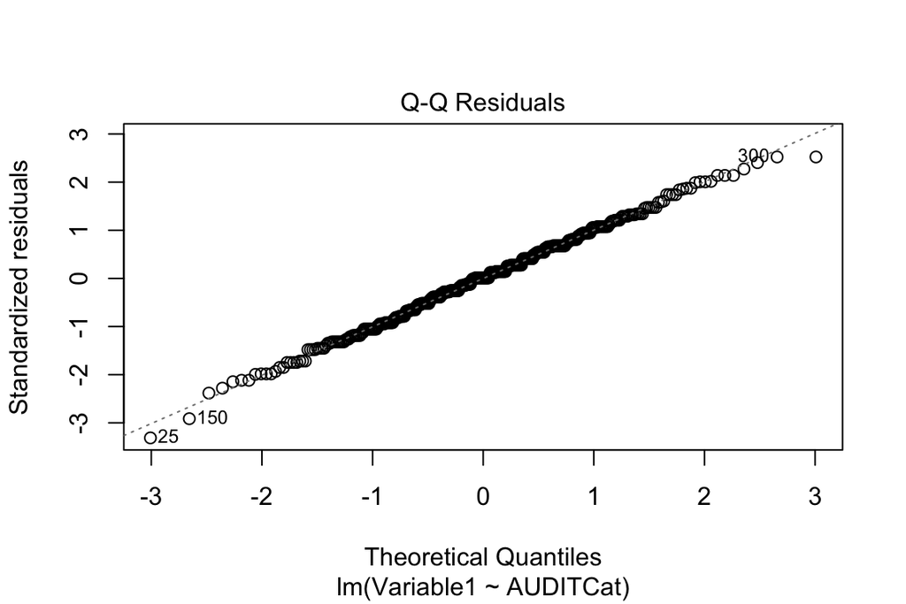

```r
plot(lmm, 2)
```

### 5.2.2 Homogeneity of variance

For Homogeneity of variance, we can either use

- Residual vs predicted plot

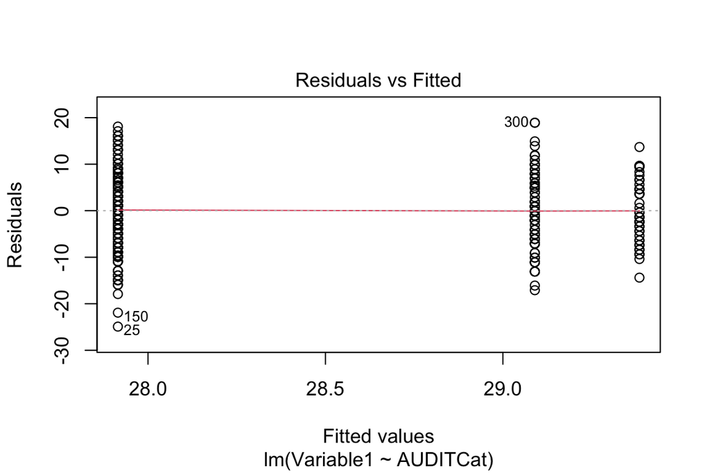

```r
plot(lmm, 1)
```

- Levene’s test

```r
leveneTest(Variable1 ~ AUDITCat, data = d)
```

```
## Levene's Test for Homogeneity of Variance (center = median)
##        Df F value Pr(>F)
## group   2    0.12   0.89
##       377
```

### 5.2.3 Homogeneity Corrections

If Homogeneity of variance is violated, we will use either Brown-Forsythe or Welch test.

```r
# Brown-Forsythe
bf.test(Variable1 ~ AUDITCat, data = d)
```

```
##
##   Brown-Forsythe Test (alpha = 0.05)
## -------------------------------------------------------------
##   data : Variable1 and AUDITCat
##
##   statistic  : 1.36
##   num df     : 2
##   denom df   : 181
##   p.value    : 0.2592
##
##   Result     : Difference is not statistically significant.
## -------------------------------------------------------------
```

```r
# Welch
welch.test(Variable1 ~ AUDITCat, data = d)
```

```
##
##   Welch's Heteroscedastic F Test (alpha = 0.05)
## -------------------------------------------------------------
##   data : Variable1 and AUDITCat
##
##   statistic  : 1.323
##   num df     : 2
##   denom df   : 109.8
##   p.value    : 0.2705
##
##   Result     : Difference is not statistically significant.
## -------------------------------------------------------------
```

### 5.2.4 Outliers

We can pretty much use the same methods for regression to check outliers for ANOVA.

## 5.3 Effect sizes

Eta-squared or omega-squared can be obtained using functions the `effectsize` package.

```r
eta_squared(lmm)
```

```
## For one-way between subjects designs, partial eta squared is equivalent
##   to eta squared. Returning eta squared.
```

```
## # Effect Size for ANOVA
##
## Parameter |     Eta2 |       95% CI
## -----------------------------------
## AUDITCat  | 6.68e-03 | [0.00, 1.00]
##
## - One-sided CIs: upper bound fixed at [1.00].
```

```r
omega_squared(lmm)
```

```
## For one-way between subjects designs, partial omega squared is
##   equivalent to omega squared. Returning omega squared.
```

```
## # Effect Size for ANOVA
##
## Parameter |   Omega2 |       95% CI
## -----------------------------------
## AUDITCat  | 1.40e-03 | [0.00, 1.00]
##
## - One-sided CIs: upper bound fixed at [1.00].
```

*Notes* : If you did not have a significant ANOVA result, you would stop at this point and just report the ANOVA result. For learning purposes, we will go ahead with Post Hoc Tests.

# 6 Pairwise comparison

ANOVA only tells us whether there is a group difference, but we don’t know which group is different from the other. When the result from ANOVA is significant (p < .05), we can use a follow-up test to find where the differences are.

To conduct follow-up test, we can use the `emmeans` package that works with both `aov` and `lm` models.

```r
em <- emmeans(lmm, pairwise ~ AUDITCat)
```

The default adjustment is TukeyHSD. We can choose another method, such as Bonferroni by adding an `adjust = Bonferroni` argument.

```r
em_b <- emmeans(lmm, pairwise ~ AUDITCat, adjust = "Bonferroni")
```

Summarise our results. We add `infer= TRUE` argument to show p-values.

- TukeyHSD

```r
summary(em, infer = TRUE)
```

```
## $emmeans
##  AUDITCat  emmean    SE  df lower.CL upper.CL t.ratio p.value
##  Abstainer   29.1 0.769 377     27.6     30.6  37.830  <.0001
##  At Risk     29.4 1.149 377     27.1     31.6  25.570  <.0001
##  Moderate    27.9 0.485 377     27.0     28.9  57.510  <.0001
##
## Confidence level used: 0.95
##
## $contrasts
##  contrast             estimate    SE  df lower.CL upper.CL t.ratio p.value
##  Abstainer - At Risk    -0.295 1.383 377   -3.548     2.96  -0.213  0.9753
##  Abstainer - Moderate    1.175 0.909 377   -0.965     3.31   1.292  0.4007
##  At Risk - Moderate      1.470 1.247 377   -1.466     4.41   1.178  0.4670
##
## Confidence level used: 0.95
## Conf-level adjustment: tukey method for comparing a family of 3 estimates
## P value adjustment: tukey method for comparing a family of 3 estimates
```

- Bonferroni

```r
summary(em_b, infer = TRUE)
```

```
## $emmeans
##  AUDITCat  emmean    SE  df lower.CL upper.CL t.ratio p.value
##  Abstainer   29.1 0.769 377     27.6     30.6  37.830  <.0001
##  At Risk     29.4 1.149 377     27.1     31.6  25.570  <.0001
##  Moderate    27.9 0.485 377     27.0     28.9  57.510  <.0001
##
## Confidence level used: 0.95
##
## $contrasts
##  contrast             estimate    SE  df lower.CL upper.CL t.ratio p.value
##  Abstainer - At Risk    -0.295 1.383 377    -3.62     3.03  -0.213  1.0000
##  Abstainer - Moderate    1.175 0.909 377    -1.01     3.36   1.292  0.5917
##  At Risk - Moderate      1.470 1.247 377    -1.53     4.47   1.178  0.7186
##
## Confidence level used: 0.95
## Conf-level adjustment: bonferroni method for 3 estimates
## P value adjustment: bonferroni method for 3 tests
```

## 6.1 Cohen’s d

Cohen’s d is the effect size for the different between two groups. It is simply a measure of the distance between two means, measured in standard deviations. When we have more than two groups, we can use `eff_size()` to calculate standardized effect sizes are typically calculated using pairwise differences of estimates. This function takes our `emmeans` model result, along with two arguments, `sigma = sigma(model_name)` to specify the *Standard Deviation* of our model, and `edf = df.residual(model_name)` to specify the equivalent degrees of freedom for the `sigma`.

```r
eff_size(em, sigma = sigma(lmm), edf = df.residual(lmm))
```

```
## Since 'object' is a list, we are using the contrasts already present.
```

```
##  contrast               effect.size    SE  df lower.CL upper.CL
##  (Abstainer - At Risk)      -0.0391 0.184 377  -0.3999    0.322
##  (Abstainer - Moderate)      0.1559 0.121 377  -0.0817    0.394
##  (At Risk - Moderate)        0.1950 0.166 377  -0.1308    0.521
##
## sigma used for effect sizes: 7.535
## Confidence level used: 0.95
```

If we only have two groups in our predictor, we can use the `cohen_d()` function (this won’t work for this model because we have three groups).

```r
cohens_d(Variable1 ~ AUDITCat, data = d)
```

```
## Error: Grouping variable y must have exactly 2 levels.
```

# 7 Visualising results

We can use the `visreg` package to graph the results from the `lm` model.

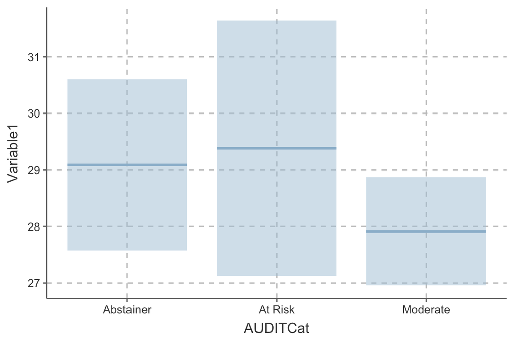

```r
visreg(lmm,
       xvar = "AUDITCat",
       overlay = TRUE, partial = FALSE, band = TRUE, rug = FALSE, gg = TRUE)
```

Alternatively, we can use the `emmip()` function to plot our result. This function takes the `emmeans` model result, rather than the `lm` model.

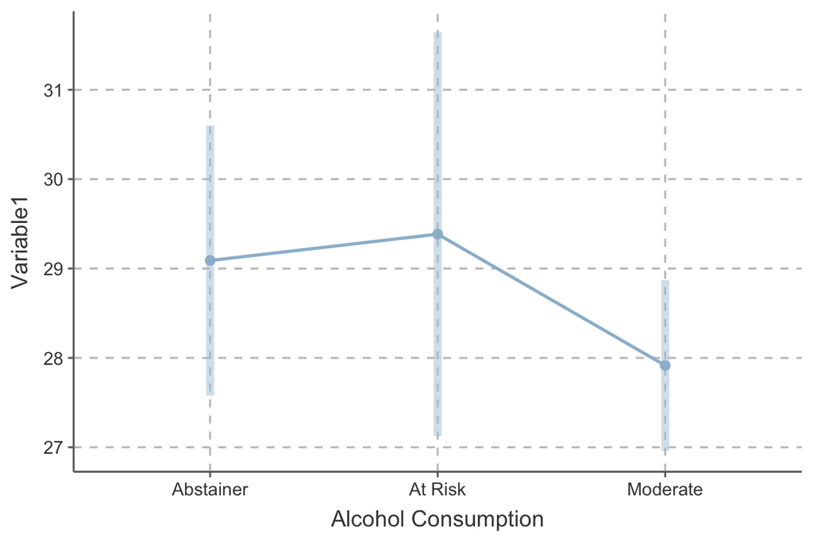

```r
emmip(em, ~ AUDITCat, CIs = TRUE) +
  ylab("Variable1") + xlab("Alcohol Consumption")
```